# Broussonetia RADseq SNPfiltR QC

Exploratory plots for choosing the next SNP filtering conditions

Generated with SNPfiltR

2026-05-05

# 1 Goal

This report uses the SNPfiltR workflow as an exploratory RADseq filtering guide. The goal is not to create a final filtered VCF in this pass. Instead, it visualizes the main quality axes that usually drive RADseq SNP filtering decisions:

- missing data by SNP and by sample,
- per-sample depth and per-SNP depth,
- genotype depth and genotype quality,
- heterozygote allele balance,
- biallelic status,
- minor allele count,
- distance thinning for linked SNPs,
- PCA and t-SNE behavior under missing-data thresholds.

The VCF is ../VCF/Broussonetia_RADseq.07_tags_refilled.vcf.gz. The metadata file is ../PRJNA437223_Broussonetia_meta.csv, and population colors use geo_loc_name_country.

# 2 Load Data

```r
vcf_path <- normalizePath(params$vcf_file)
metadata_path <- normalizePath(params$metadata_file)

vcf <- read.vcfR(vcf_path, verbose = FALSE)
vcf@gt[, -1] <- gsub("^([0-9.])\\|([0-9.])", "\\1/\\2", vcf@gt[, -1])
metadata <- read.csv(metadata_path, check.names = FALSE)

sample_ids <- colnames(vcf@gt)[-1]
popmap <- metadata |>
  transmute(
    id = Run,
    pop = .data[[params$pop_column]],
    organism = Organism,
    sample_name = `Sample Name`,
    locality = geo_loc_name,
    haplotype = haplotype
  ) |>
  filter(id %in% sample_ids) |>
  mutate(pop = if_else(is.na(pop) | pop == "", "missing", pop)) |>
  arrange(match(id, sample_ids))

stopifnot(identical(popmap$id, sample_ids))

vcf_summary <- tibble(
  metric = c("variants", "samples", "scaffolds", "metadata rows matched"),
  value = c(
    nrow(vcf@fix),
    length(sample_ids),
    n_distinct(vcf@fix[, "CHROM"]),
    nrow(popmap)
  )
)

datatable(vcf_summary, rownames = FALSE, options = list(dom = "t"))
```

| metric | value |
| --- | --- |
| variants | 203548 |
| samples | 171 |
| scaffolds | 18 |
| metadata rows matched | 171 |

The metadata match check is strict: every VCF sample must appear in the metadata, and the report stops if the order cannot be aligned.

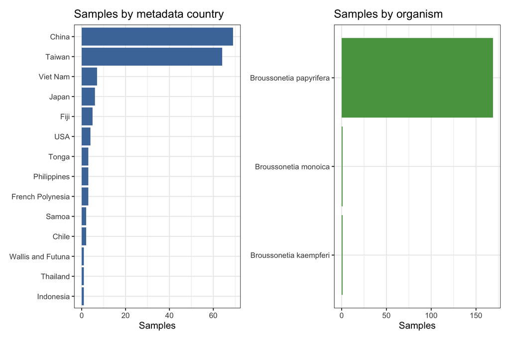

```r
p_country <- popmap |>
  count(pop, sort = TRUE) |>
  ggplot(aes(x = reorder(pop, n), y = n)) +
  geom_col(fill = "#4C78A8") +
  coord_flip() +
  labs(x = NULL, y = "Samples", title = "Samples by metadata country")

p_organism <- popmap |>
  count(organism, sort = TRUE) |>
  ggplot(aes(x = reorder(organism, n), y = n)) +
  geom_col(fill = "#59A14F") +
  coord_flip() +
  labs(x = NULL, y = "Samples", title = "Samples by organism")

p_country + p_organism
```

# 3 Genotype Matrices Used For Parameter Summaries

```r
gt <- extract.gt(vcf, element = "GT", as.numeric = FALSE)
dp <- extract.gt(vcf, element = "DP", as.numeric = TRUE)
gq <- extract.gt(vcf, element = "GQ", as.numeric = TRUE)
ad <- extract.gt(vcf, element = "AD", as.numeric = FALSE)

called <- !is.na(gt) & !gt %in% c("./.", ".|.", ".")
variant_missing <- rowMeans(!called)
sample_missing <- colMeans(!called)
sample_mean_depth <- colMeans(dp, na.rm = TRUE)
variant_mean_depth <- rowMeans(dp, na.rm = TRUE)

field_summary <- tibble(
  field = c("GT", "DP", "GQ", "AD"),
  non_missing_cells = c(sum(!is.na(gt)), sum(!is.na(dp)), sum(!is.na(gq)), sum(!is.na(ad))),
  total_cells = length(gt),
  proportion_non_missing = non_missing_cells / total_cells
)

datatable(field_summary, rownames = FALSE, options = list(pageLength = 4, dom = "t"))
```

| field | non_missing_cells | total_cells | proportion_non_missing |
| --- | --- | --- | --- |
| GT | 16542140 | 34806708 | 0.4752572406445332 |
| DP | 34799498 | 34806708 | 0.9997928560207417 |
| GQ | 34799498 | 34806708 | 0.9997928560207417 |
| AD | 34806708 | 34806708 | 1 |

# 4 Missing Data By SNP

```r
missing_snp_tbl <- missing_by_snp(vcf)
```

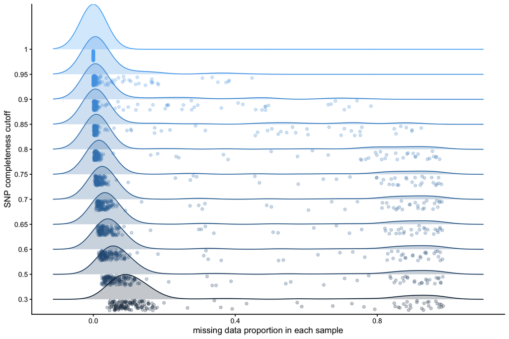

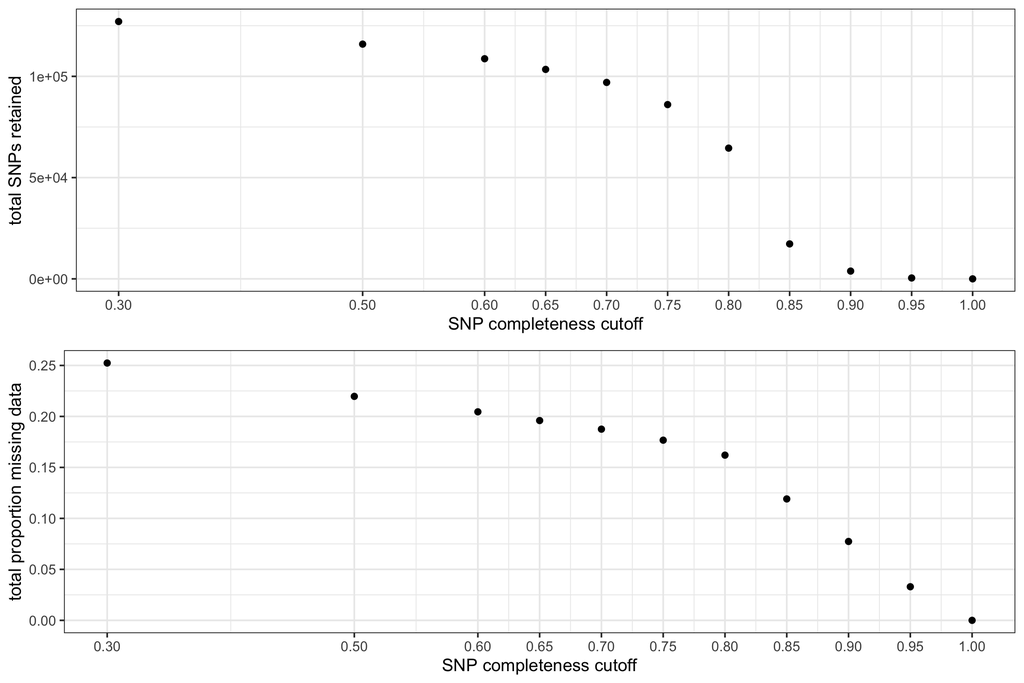

```r
datatable(missing_snp_tbl, rownames = FALSE, options = list(pageLength = 10))
```

| filt | missingness | snps.retained |
| --- | --- | --- |
| 0.3 | 0.25237288487382 | 127071 |
| 0.5 | 0.219667961783215 | 115910 |
| 0.6 | 0.204526599732852 | 108703 |
| 0.65 | 0.195962916411529 | 103430 |
| 0.7 | 0.187516597575538 | 97003 |
| 0.75 | 0.176699058948026 | 86054 |
| 0.8 | 0.162016106625473 | 64553 |
| 0.85 | 0.119063880300914 | 17262 |
| 0.9 | 0.0773708113901868 | 3841 |
| 0.95 | 0.0329685068941467 | 436 |

[output cut: 1 more lines]

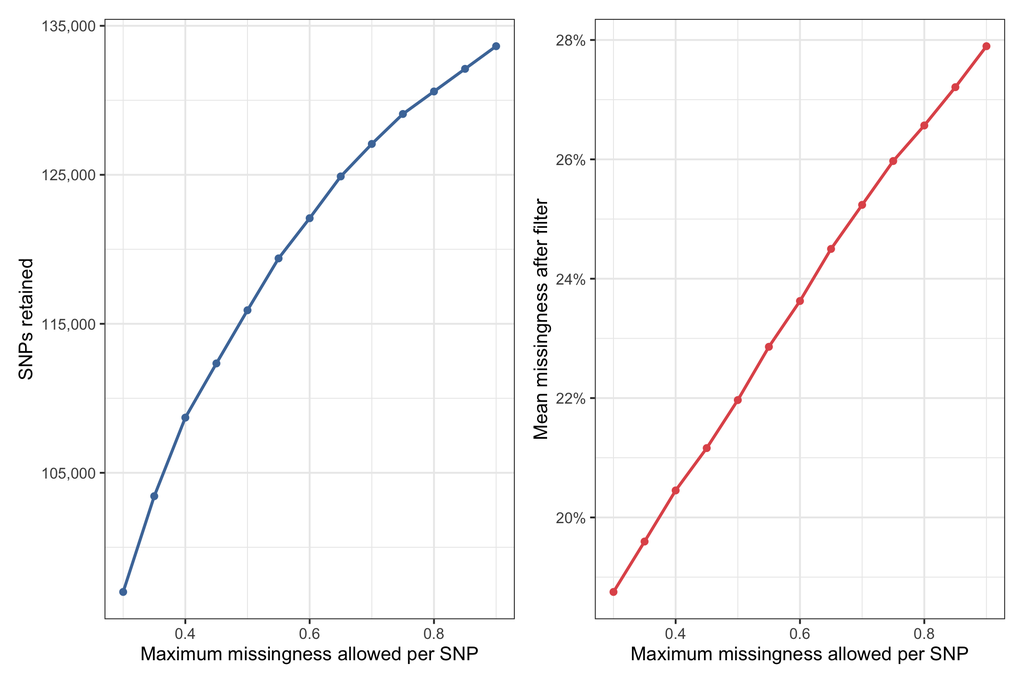

```r
candidate_snp_missing <- seq(0.3, 0.9, by = 0.05)
missing_snp_grid <- tibble(cutoff = candidate_snp_missing) |>
  mutate(
    snps_retained = map_int(cutoff, ~ sum(variant_missing <= .x)),
    percent_retained = snps_retained / nrow(vcf@fix),
    mean_missing_after = map_dbl(cutoff, ~ mean(variant_missing[variant_missing <= .x]))
  )

p_retained <- missing_snp_grid |>
  ggplot(aes(cutoff, snps_retained)) +
  geom_line(color = "#4C78A8", linewidth = 0.9) +
  geom_point(color = "#4C78A8") +
  scale_y_continuous(labels = comma) +
  labs(x = "Maximum missingness allowed per SNP", y = "SNPs retained")

p_missing <- missing_snp_grid |>
  ggplot(aes(cutoff, mean_missing_after)) +
  geom_line(color = "#E15759", linewidth = 0.9) +
  geom_point(color = "#E15759") +
  scale_y_continuous(labels = percent) +
  labs(x = "Maximum missingness allowed per SNP", y = "Mean missingness after filter")

p_retained + p_missing
```

# 5 Missing Data By Sample

Samples with very high missingness often cannot be rescued by SNP-level missingness filters. For RADseq, this is usually one of the most important early decisions.

```r
missing_sample_obj <- missing_by_sample(vcf, popmap = popmap[, c("id", "pop")])
```

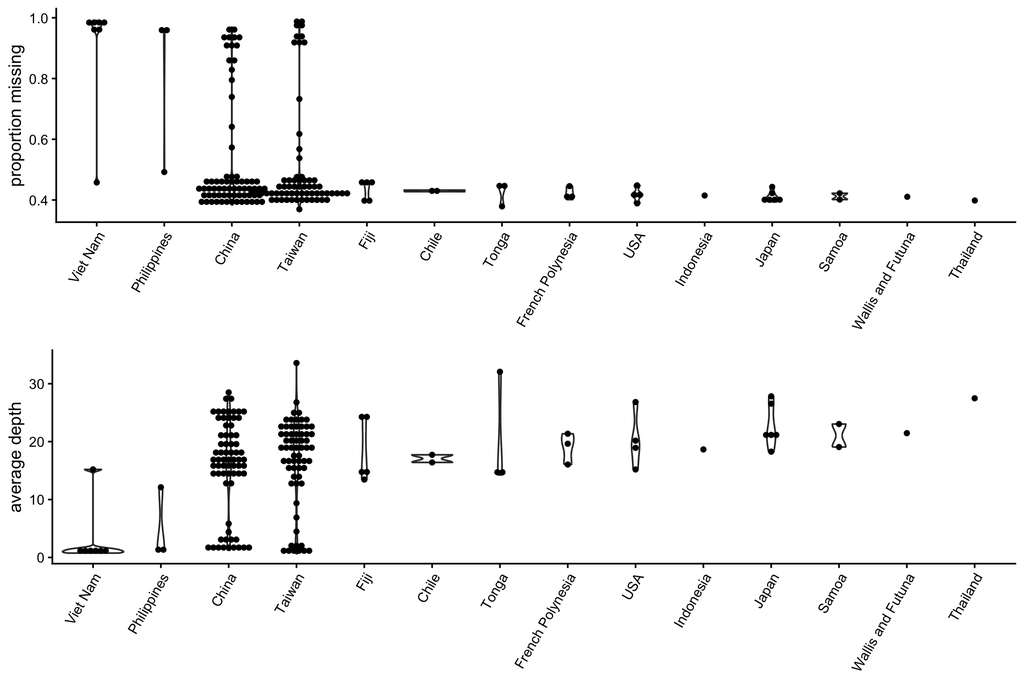

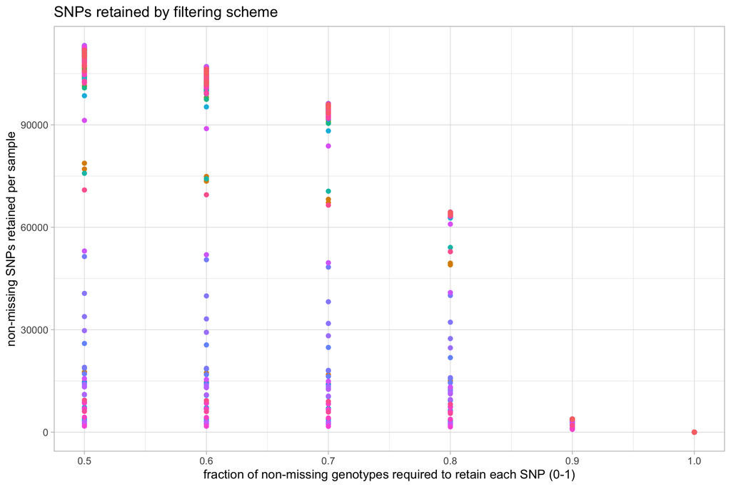

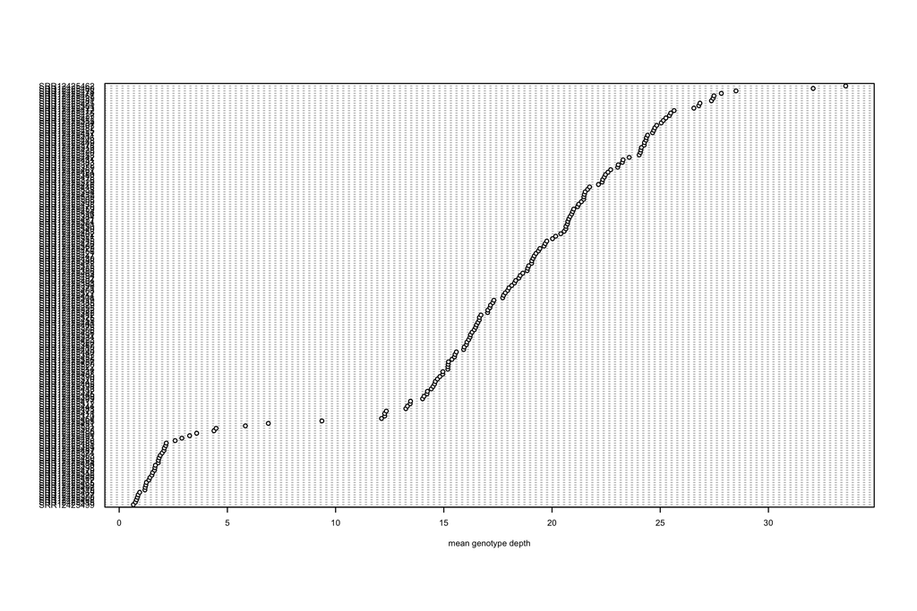

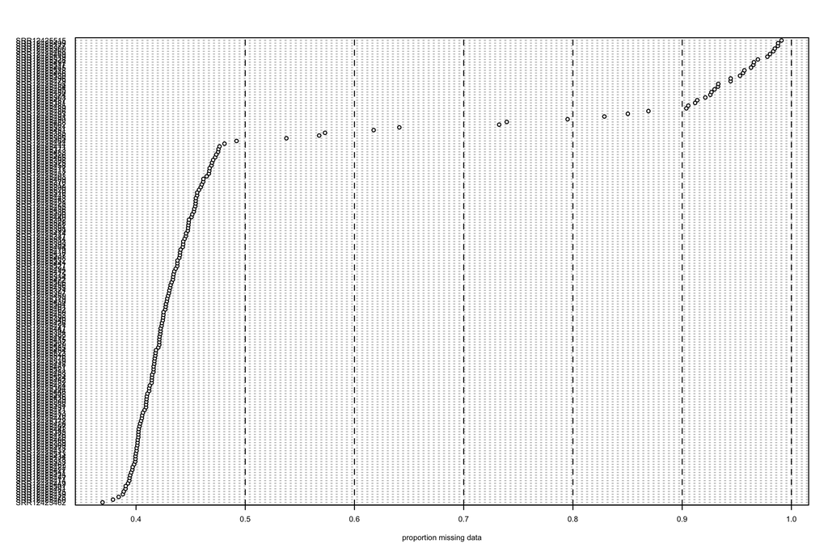

```r
sample_qc <- as_tibble(missing_sample_obj$unfiltered.stats, rownames = "id") |>
  select(id, prop.missing, mean.depth) |>
  left_join(popmap, by = "id") |>
  arrange(desc(prop.missing))

datatable(sample_qc, rownames = FALSE, options = list(pageLength = 15))
```

| id | prop.missing | mean.depth | pop | organism | sample_name | locality | haplotype |
| --- | --- | --- | --- | --- | --- | --- | --- |
| SRR12425515 | 0.9909603631575844 | 0.7502763516667076 | Viet Nam | Broussonetia papyrifera | Liu131_1_Vietnam_KhanhHoa_cp34 | Viet Nam: Nha Trang\, Khanh Hoa | cp34 |
| SRR12425499 | 0.9878505315699491 | 0.6549216892330064 | Taiwan | Broussonetia papyrifera | I45_2_Taiwan_Yunlin_cp10 | Taiwan: Lunbei Township\, Yunlin County | cp10 |
| SRR12425377 | 0.9876638434177688 | 0.8760618045149721 | Taiwan | Broussonetia papyrifera | L103_4_Taiwan_Kaohsiung_cp16 | Taiwan: Ciaotou District\, Kaohsiung City | cp16 |
| SRR12425500 | 0.9848143926739639 | 0.8421973184500268 | Taiwan | Broussonetia papyrifera | LD1_Taiwan_Taitung_Ludao_cp09 | Taiwan: Ludao Township\, Taitung County | cp09 |
| SRR12425468 | 0.9834093186865015 | 0.8003743625519538 | Viet Nam | Broussonetia papyrifera | LiuBN3_Vietnam_BacNinh_cp34 | Viet Nam: Bac Ninh\, Bac Ninh | cp34 |
| SRR12425469 | 0.9803977440210663 | 0.9469280467732822 | Viet Nam | Broussonetia papyrifera | LiuLL_Vietnam_HaNoi_cp21 | Viet Nam: Long Bien\, Ha Noi | cp21 |
| SRR12425519 | 0.9780051879654922 | 1.18799836886297 | Viet Nam | Broussonetia papyrifera | Liu131_2_Vietnam_KhanhHoa_cp20 | Viet Nam: Nha Trang\, Khanh Hoa | cp20 |
| SRR12425528 | 0.9693389274274372 | 1.234225381867848 | China | Broussonetia papyrifera | KFC2990_Guangxi_Guiling_cp21 | China: Lingui\, Guiling\, Guangxi Province | cp21 |
| SRR12425497 | 0.965713246998251 | 1.202363171858111 | Taiwan | Broussonetia papyrifera | I43_2_Taiwan_Yunlin_cp13 | Taiwan: Dongshih Township\, Yunlin County | cp13 |
| SRR12425517 | 0.9652121366950301 | 1.37255990605669 | Viet Nam | Broussonetia papyrifera | Liu125_Vietnam_QuangBinh_cp34 | Viet Nam: Bo Trach\, Quang Binh | cp34 |

[output cut: 161 more lines]

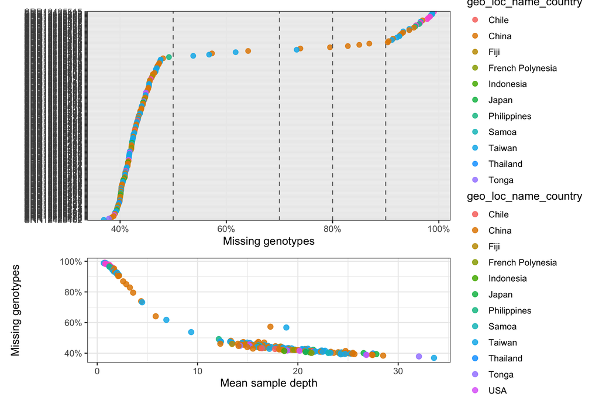

```r
p_sample_missing <- sample_qc |>
  mutate(id = fct_reorder(id, prop.missing)) |>
  ggplot(aes(id, prop.missing, color = pop)) +
  geom_point(size = 2.2, alpha = 0.85) +
  geom_hline(yintercept = c(0.5, 0.7, 0.8, 0.9), linetype = "dashed", color = "grey45") +
  coord_flip() +
  scale_y_continuous(labels = percent) +
  labs(x = NULL, y = "Missing genotypes", color = params$pop_column)

p_depth_missing <- sample_qc |>
  ggplot(aes(mean.depth, prop.missing, color = pop)) +
  geom_point(size = 2.4, alpha = 0.85) +
  scale_y_continuous(labels = percent) +
  labs(x = "Mean sample depth", y = "Missing genotypes", color = params$pop_column)

p_sample_missing / p_depth_missing + plot_layout(heights = c(2, 1))
```

```r
sample_cutoffs <- c(0.5, 0.6, 0.7, 0.8, 0.9)
sample_threshold_tbl <- tibble(max_sample_missing = sample_cutoffs) |>
  mutate(
    samples_retained = map_int(max_sample_missing, ~ sum(sample_missing <= .x)),
    samples_removed = length(sample_ids) - samples_retained
  )

datatable(sample_threshold_tbl, rownames = FALSE, options = list(dom = "t"))
```

| max_sample_missing | samples_retained | samples_removed |
| --- | --- | --- |
| 0.5 | 134 | 37 |
| 0.6 | 137 | 34 |
| 0.7 | 139 | 32 |
| 0.8 | 142 | 29 |
| 0.9 | 145 | 26 |

# 6 Depth And Genotype Quality

Classic RADseq hard filtering usually removes individual genotype calls below a minimum depth and genotype quality. The heatmap below shows how much missingness would be introduced by common depth and GQ thresholds.

```r
depth_grid <- c(3, 5, 8, 10)
gq_grid <- c(10, 20, 30, 40)

hard_filter_grid <- crossing(min_depth = depth_grid, min_gq = gq_grid) |>
  mutate(
    callable_cells = map2_int(min_depth, min_gq, ~ sum(called & dp >= .x & gq >= .y, na.rm = TRUE)),
    total_called_before = sum(called),
    retained_called_fraction = callable_cells / total_called_before,
    total_matrix_missing_after = 1 - callable_cells / length(called)
  )

datatable(hard_filter_grid, rownames = FALSE, options = list(pageLength = 16, dom = "t"))
```

| min_depth | min_gq | callable_cells | total_called_before | retained_called_fraction | total_matrix_missing_after |
| --- | --- | --- | --- | --- | --- |
| 3 | 10 | 16542140 | 16542140 | 1 | 0.5247427593554668 |
| 3 | 20 | 16542140 | 16542140 | 1 | 0.5247427593554668 |
| 3 | 30 | 15418771 | 16542140 | 0.9320904671342402 | 0.557017256558707 |
| 3 | 40 | 14114375 | 16542140 | 0.8532375496761604 | 0.5944926765266052 |
| 5 | 10 | 16542140 | 16542140 | 1 | 0.5247427593554668 |
| 5 | 20 | 16542140 | 16542140 | 1 | 0.5247427593554668 |
| 5 | 30 | 15418771 | 16542140 | 0.9320904671342402 | 0.557017256558707 |
| 5 | 40 | 14114375 | 16542140 | 0.8532375496761604 | 0.5944926765266052 |
| 8 | 10 | 16111063 | 16542140 | 0.9739406751484391 | 0.5371276421774791 |
| 8 | 20 | 16111063 | 16542140 | 0.9739406751484391 | 0.5371276421774791 |

[output cut: 6 more lines]

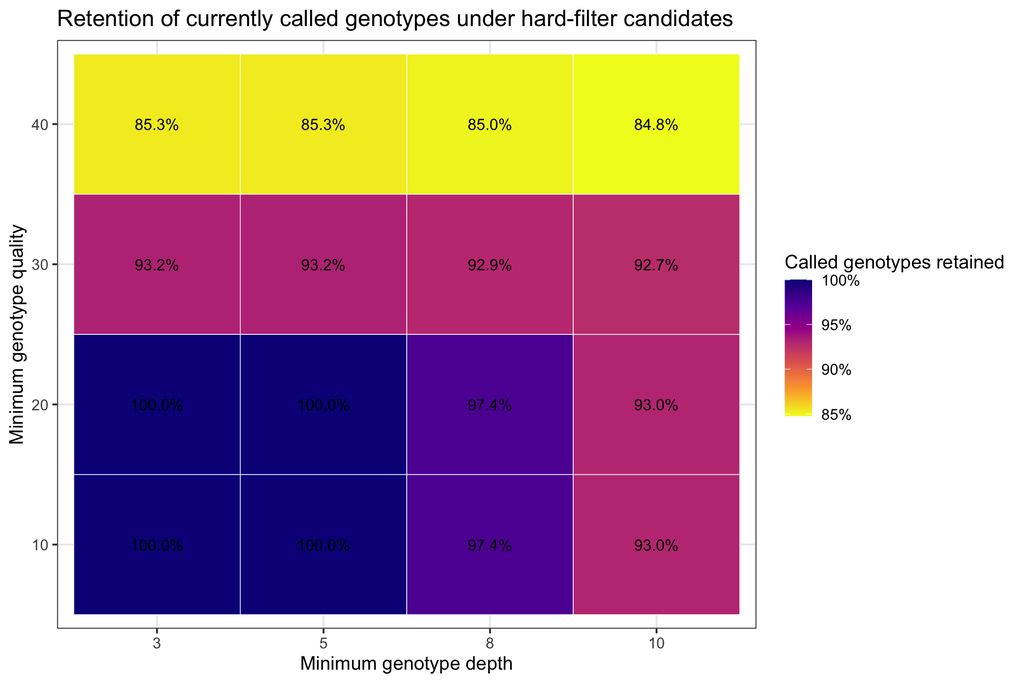

```r
hard_filter_grid |>
  ggplot(aes(factor(min_depth), factor(min_gq), fill = retained_called_fraction)) +
  geom_tile(color = "white") +
  geom_text(aes(label = percent(retained_called_fraction, accuracy = 0.1)), size = 3.5) +
  scale_fill_viridis_c(labels = percent, option = "C", direction = -1) +
  labs(
    x = "Minimum genotype depth",
    y = "Minimum genotype quality",
    fill = "Called genotypes retained",
    title = "Retention of currently called genotypes under hard-filter candidates"
  )
```

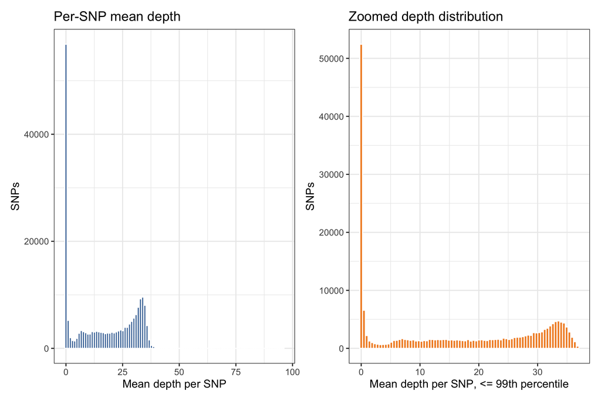

```r
depth_df <- tibble(
  variant_mean_depth = variant_mean_depth,
  variant_missing = variant_missing
) |>
  filter(is.finite(variant_mean_depth))

p_variant_depth <- depth_df |>
  ggplot(aes(variant_mean_depth)) +
  geom_histogram(bins = 100, fill = "#4C78A8", color = "white") +
  scale_x_continuous(labels = comma) +
  labs(x = "Mean depth per SNP", y = "SNPs", title = "Per-SNP mean depth")

p_variant_depth_zoom <- depth_df |>
  filter(variant_mean_depth <= quantile(variant_mean_depth, 0.99, na.rm = TRUE)) |>
  ggplot(aes(variant_mean_depth)) +
  geom_histogram(bins = 80, fill = "#F28E2B", color = "white") +
  labs(x = "Mean depth per SNP, <= 99th percentile", y = "SNPs", title = "Zoomed depth distribution")

p_variant_depth + p_variant_depth_zoom
```

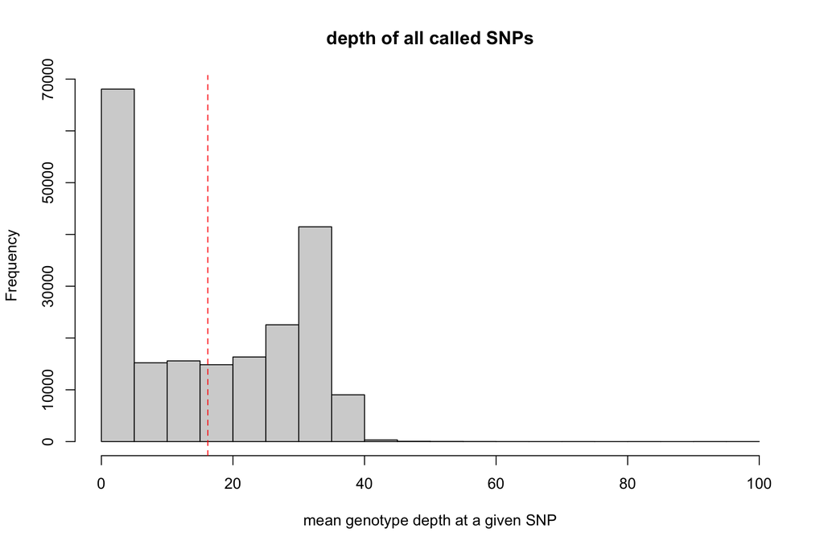

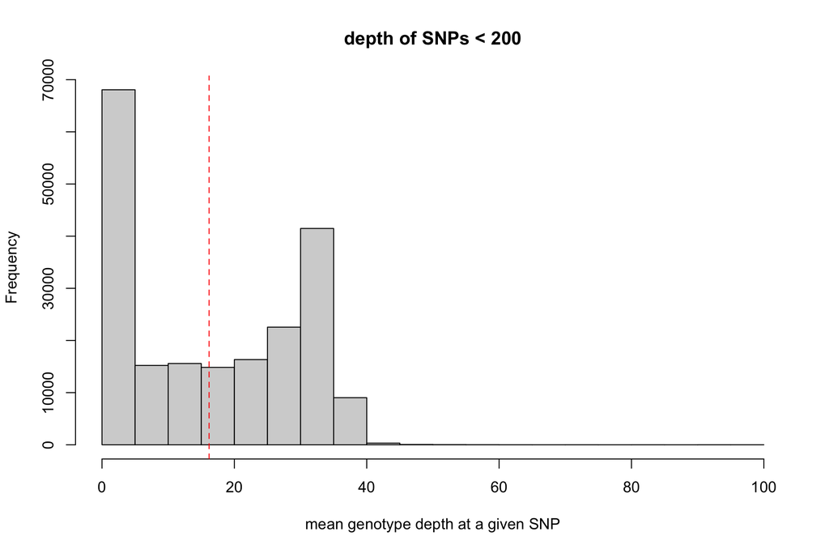

```r
max_depth(vcf)
```

```r
depth_threshold_tbl <- tibble(
  rule = c("95th percentile", "97.5th percentile", "99th percentile", "mean + 2 sd", "mean + 3 sd"),
  max_mean_depth = c(
    quantile(variant_mean_depth, 0.95, na.rm = TRUE),
    quantile(variant_mean_depth, 0.975, na.rm = TRUE),
    quantile(variant_mean_depth, 0.99, na.rm = TRUE),
    mean(variant_mean_depth, na.rm = TRUE) + 2 * sd(variant_mean_depth, na.rm = TRUE),
    mean(variant_mean_depth, na.rm = TRUE) + 3 * sd(variant_mean_depth, na.rm = TRUE)
  )
) |>
  mutate(snps_retained = map_int(max_mean_depth, ~ sum(variant_mean_depth <= .x, na.rm = TRUE)))

datatable(depth_threshold_tbl, rownames = FALSE, options = list(dom = "t"))
```

| rule | max_mean_depth | snps_retained |
| --- | --- | --- |
| 95th percentile | 34.90643274853801 | 193400 |
| 97.5th percentile | 35.70175438596491 | 198462 |
| 99th percentile | 36.7953216374269 | 201522 |
| mean + 2 sd | 43.40385630641759 | 203389 |
| mean + 3 sd | 57.0163161196371 | 203514 |

# 7 Allele Balance

For called heterozygotes in a diploid RADseq dataset, the reference allele fraction should center near 0.5. Extreme values can reflect allele dropout, mismapping, paralogy, or low-depth genotypes.

```r
het <- gt %in% c("0/1", "1/0", "0|1", "1|0")
ad_parts <- str_split_fixed(as.vector(ad), ",", 2)
ref_depth <- suppressWarnings(as.numeric(ad_parts[, 1]))
alt_depth <- suppressWarnings(as.numeric(ad_parts[, 2]))
ab <- ref_depth / (ref_depth + alt_depth)
ab_het <- ab[as.vector(het) & is.finite(ab)]

ab_tbl <- tibble(ref_allele_fraction = ab_het) |>
  mutate(
    pass_25_75 = between(ref_allele_fraction, 0.25, 0.75),
    pass_30_70 = between(ref_allele_fraction, 0.30, 0.70),
    pass_20_80 = between(ref_allele_fraction, 0.20, 0.80)
  )

tibble(
  filter = c("0.20-0.80", "0.25-0.75", "0.30-0.70"),
  heterozygotes_retained = c(sum(ab_tbl$pass_20_80), sum(ab_tbl$pass_25_75), sum(ab_tbl$pass_30_70)),
  heterozygotes_total = nrow(ab_tbl)
) |>
  mutate(retained_fraction = heterozygotes_retained / heterozygotes_total) |>
  datatable(rownames = FALSE, options = list(dom = "t"))
```

| filter | heterozygotes_retained | heterozygotes_total | retained_fraction |
| --- | --- | --- | --- |
| 0.20-0.80 | 1076332 | 1076332 | 1 |
| 0.25-0.75 | 1076332 | 1076332 | 1 |
| 0.30-0.70 | 977644 | 1076332 | 0.908310818595006 |

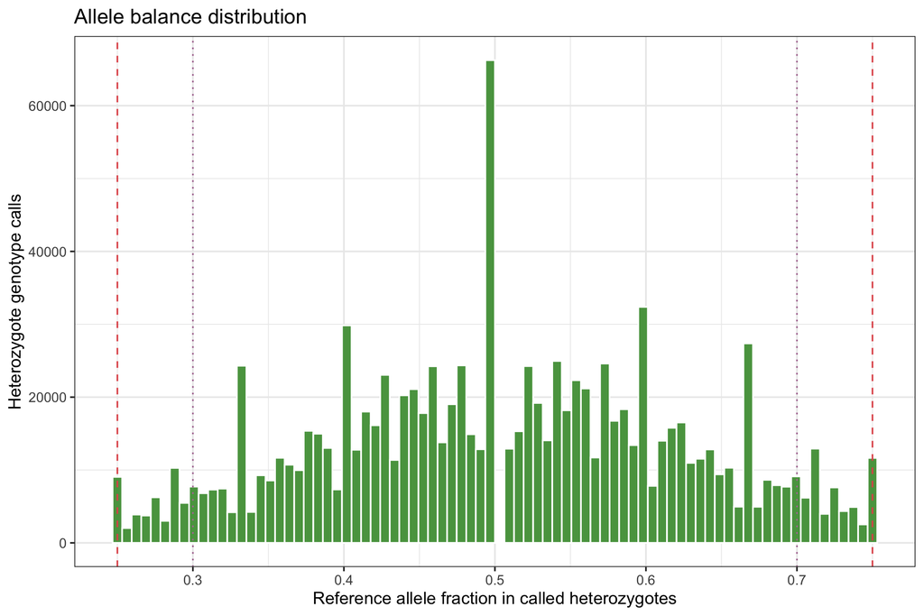

```r
ggplot(ab_tbl, aes(ref_allele_fraction)) +
  geom_histogram(bins = 80, fill = "#59A14F", color = "white") +
  geom_vline(xintercept = c(0.25, 0.75), linetype = "dashed", color = "#E15759") +
  geom_vline(xintercept = c(0.30, 0.70), linetype = "dotted", color = "#B07AA1") +
  labs(
    x = "Reference allele fraction in called heterozygotes",
    y = "Heterozygote genotype calls",
    title = "Allele balance distribution"
  )
```

SNPfiltR’s default allele balance filter is 0.25-0.75 when no explicit ratio is supplied. The chunk below runs that default once as a check and reports the resulting missingness.

```r
vcf_ab_default <- filter_allele_balance(vcf)
```

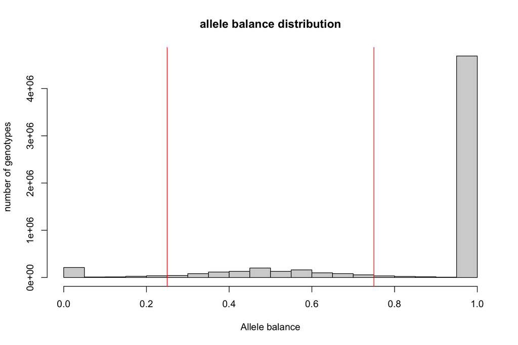

```r
gt_ab_default <- extract.gt(vcf_ab_default, element = "GT", as.numeric = FALSE)
tibble(
  filter = "SNPfiltR default allele balance 0.25-0.75",
  missing_before = mean(!called),
  missing_after = mean(is.na(gt_ab_default) | gt_ab_default %in% c("./.", ".|.", "."))
) |>
  datatable(rownames = FALSE, options = list(dom = "t"))
```

| filter | missing_before | missing_after |
| --- | --- | --- |
| SNPfiltR default allele balance 0.25-0.75 | 0.5247427593554668 | 0.5247427593554668 |

# 8 Biallelic SNPs And Minor Allele Count

Most downstream population-genetic programs expect biallelic SNPs. Minor allele count then controls singleton/doubleton retention and helps remove invariant sites that may appear after sample filtering.

```r
biallelic <- !str_detect(vcf@fix[, "ALT"], ",")
tibble(
  category = c("biallelic", "multiallelic"),
  snps = c(sum(biallelic), sum(!biallelic))
) |>
  mutate(percent = snps / sum(snps)) |>
  datatable(rownames = FALSE, options = list(dom = "t"))
```

| category | snps | percent |
| --- | --- | --- |
| biallelic | 203548 | 1 |
| multiallelic | 0 | 0 |

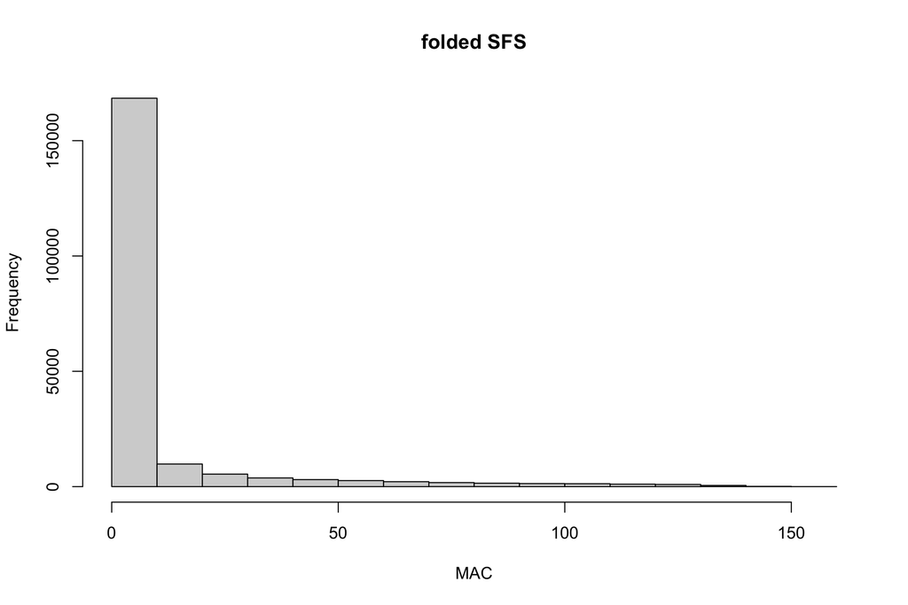

```
## ***** Object of Class vcfR *****
## 171 samples
## 18 CHROMs
## 203,548 variants
## Object size: 435.7 Mb
## 0 percent missing data
## *****        *****         *****
```

```r
min_mac(vcf)
```

```r
gt_numeric <- gt
gt_numeric[gt_numeric %in% c("0/0", "0|0")] <- "0"
gt_numeric[gt_numeric %in% c("0/1", "1/0", "0|1", "1|0")] <- "1"
gt_numeric[gt_numeric %in% c("1/1", "1|1")] <- "2"
alt_counts <- rowSums(matrix(as.numeric(gt_numeric), nrow = nrow(gt_numeric)), na.rm = TRUE)
alleles_called <- 2 * rowSums(called)
minor_allele_count <- pmin(alt_counts, alleles_called - alt_counts)

mac_cutoffs <- c(1, 2, 3, 5, 10)
mac_tbl <- tibble(min_mac = mac_cutoffs) |>
  mutate(snps_retained = map_int(min_mac, ~ sum(minor_allele_count >= .x, na.rm = TRUE)))

datatable(mac_tbl, rownames = FALSE, options = list(dom = "t"))
```

| min_mac | snps_retained |
| --- | --- |
| 1 | 126411 |
| 2 | 76760 |
| 3 | 62723 |
| 5 | 49156 |
| 10 | 36633 |

# 9 Distance Thinning

RADseq loci can include linked SNPs on the same assembled tag or scaffold. Distance thinning is especially useful before analyses that assume weak linkage, such as STRUCTURE-like clustering.

```r
thin_one <- function(chrom, pos, min_distance) {
  keep <- logical(length(pos))
  last_pos <- -Inf
  for (i in seq_along(pos)) {
    if (pos[i] - last_pos > min_distance) {
      keep[i] <- TRUE
      last_pos <- pos[i]
    }
  }
  keep
}

pos_tbl <- tibble(
  chrom = vcf@fix[, "CHROM"],
  pos = as.integer(vcf@fix[, "POS"]),
  row_id = seq_len(nrow(vcf@fix))
) |>
  arrange(chrom, pos)

distance_tbl <- tibble(min_distance_bp = c(100, 250, 500, 1000, 5000, 10000)) |>
  mutate(
    snps_retained = map_int(min_distance_bp, function(d) {
      pos_tbl |>
        group_by(chrom) |>
        summarise(retained = sum(thin_one(chrom, pos, d)), .groups = "drop") |>
        summarise(total = sum(retained), .groups = "drop") |>
        pull(total)
    }),
    percent_retained = snps_retained / nrow(vcf@fix)
  )

datatable(distance_tbl, rownames = FALSE, options = list(dom = "t"))
```

| min_distance_bp | snps_retained | percent_retained |
| --- | --- | --- |
| 100 | 83729 | 0.4113476919448975 |
| 250 | 64609 | 0.317414074321536 |
| 500 | 60504 | 0.2972468410399512 |
| 1000 | 53958 | 0.265087350403836 |
| 5000 | 31457 | 0.1545434000825358 |
| 10000 | 21617 | 0.1062009943600527 |

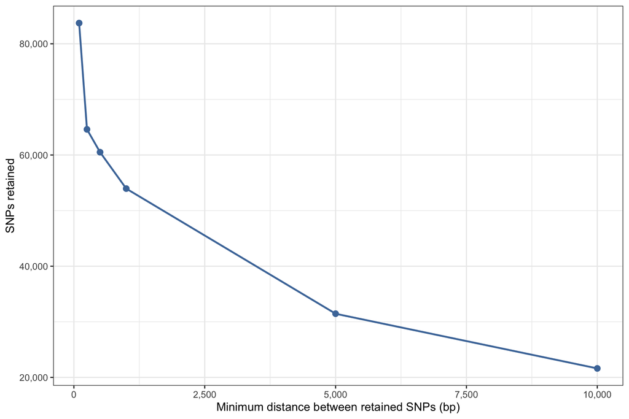

```r
distance_tbl |>
  ggplot(aes(min_distance_bp, snps_retained)) +
  geom_line(color = "#4C78A8", linewidth = 0.9) +
  geom_point(color = "#4C78A8", size = 2.5) +
  scale_x_continuous(labels = comma) +
  scale_y_continuous(labels = comma) +
  labs(x = "Minimum distance between retained SNPs (bp)", y = "SNPs retained")
```

# 10 Missingness And Structure Plots

To keep this report practical, the structure diagnostics use at most 20000 SNPs after a light exploratory prefilter. The SNP subset is deterministic because the random seed is fixed in the setup chunk.

```r
structure_keep_samples <- sample_qc |>
  filter(prop.missing <= 0.8) |>
  pull(id)

structure_keep_snps <- which(variant_missing <= 0.8 & minor_allele_count >= 1 & biallelic)
if (length(structure_keep_snps) > params$structure_snp_limit) {
  structure_keep_snps <- sort(sample(structure_keep_snps, params$structure_snp_limit))
}

vcf_structure <- vcf[structure_keep_snps, c(TRUE, sample_ids %in% structure_keep_samples)]
popmap_structure <- popmap |>
  filter(id %in% structure_keep_samples) |>
  select(id, pop)

gt_structure <- extract.gt(vcf_structure, element = "GT", as.numeric = FALSE)
called_structure <- !is.na(gt_structure) & !gt_structure %in% c("./.", ".|.", ".")
gt_structure_numeric <- gt_structure
gt_structure_numeric[gt_structure_numeric %in% c("0/0")] <- "0"
gt_structure_numeric[gt_structure_numeric %in% c("0/1", "1/0")] <- "1"
gt_structure_numeric[gt_structure_numeric %in% c("1/1")] <- "2"
alt_counts_structure <- rowSums(
  matrix(as.numeric(gt_structure_numeric), nrow = nrow(gt_structure_numeric)),
  na.rm = TRUE
)
alleles_called_structure <- 2 * rowSums(called_structure)
mac_structure <- pmin(alt_counts_structure, alleles_called_structure - alt_counts_structure)
vcf_structure <- vcf_structure[mac_structure >= 1, ]

tibble(
  metric = c("samples retained for structure diagnostics", "SNPs retained for structure diagnostics"),
  value = c(length(structure_keep_samples), nrow(vcf_structure@fix))
) |>
  datatable(rownames = FALSE, options = list(dom = "t"))
```

| metric | value |
| --- | --- |
| samples retained for structure diagnostics | 142 |
| SNPs retained for structure diagnostics | 19426 |

```r
assess_missing_data_pca(
  vcfR = vcf_structure,
  popmap = popmap_structure,
  thresholds = c(0.5, 0.7, 0.8),
  clustering = TRUE
)
```

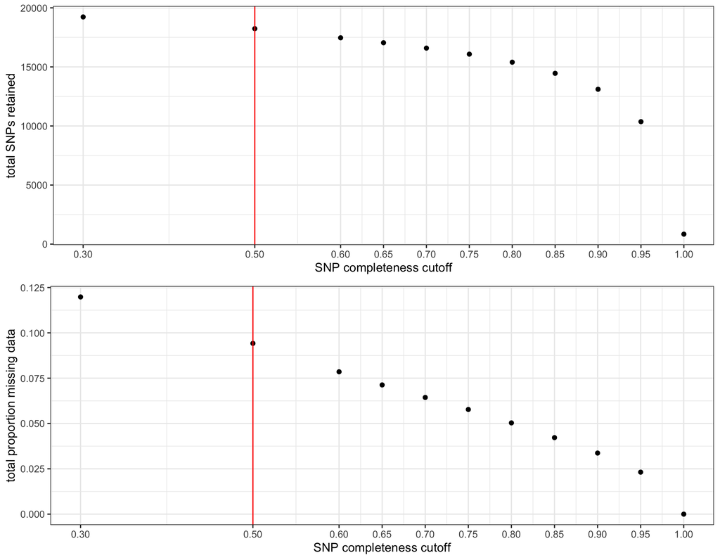

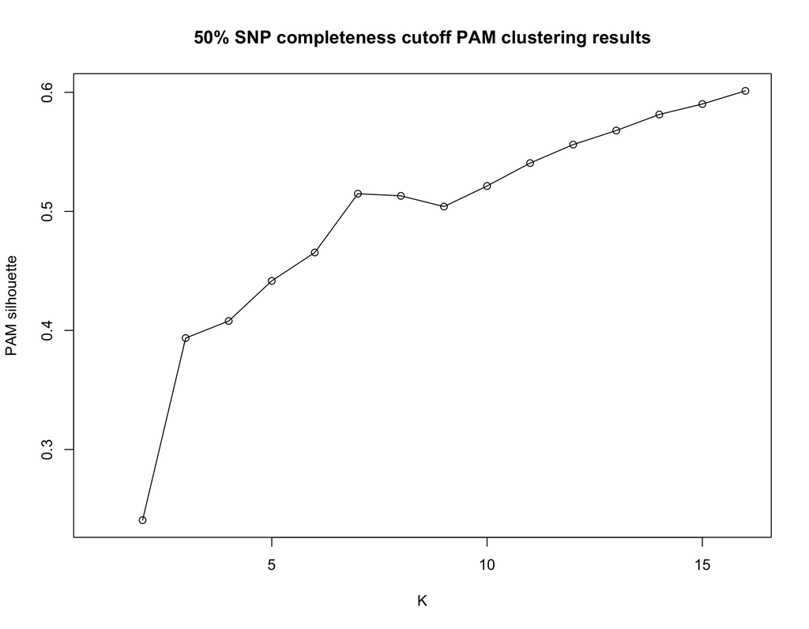

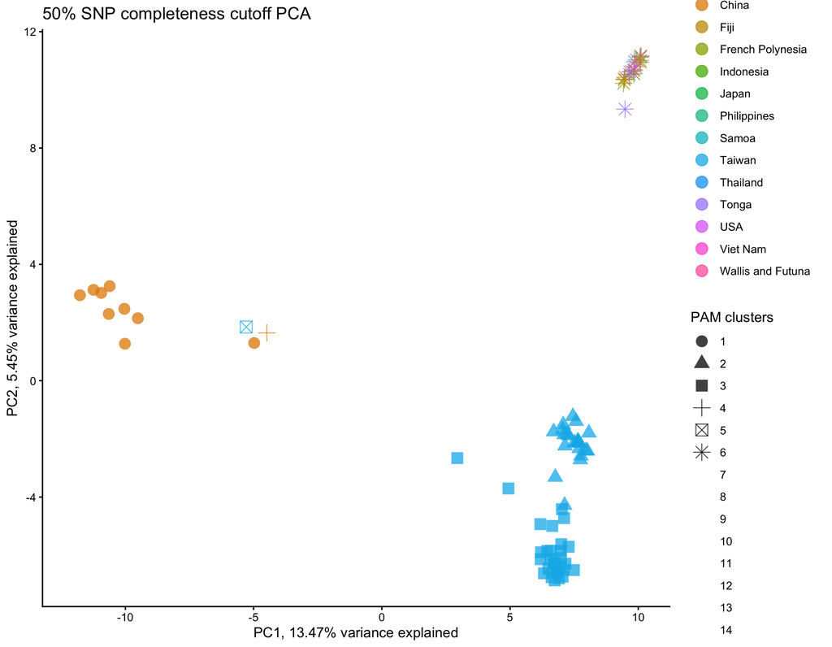

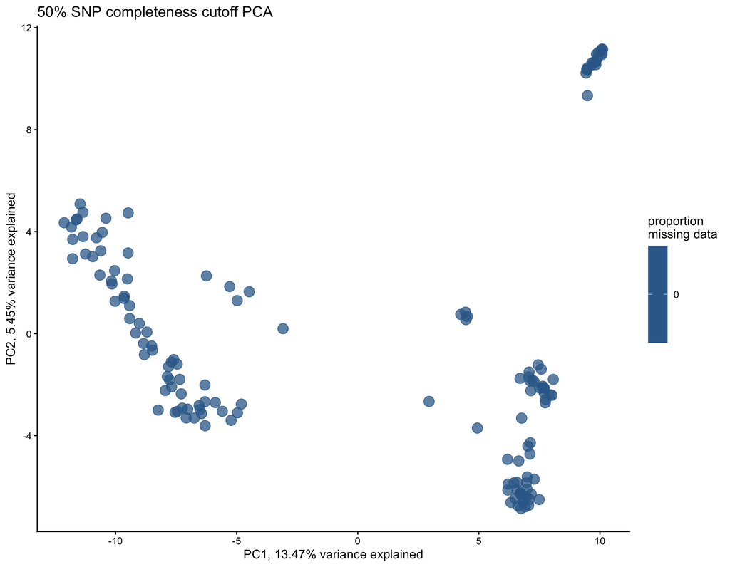

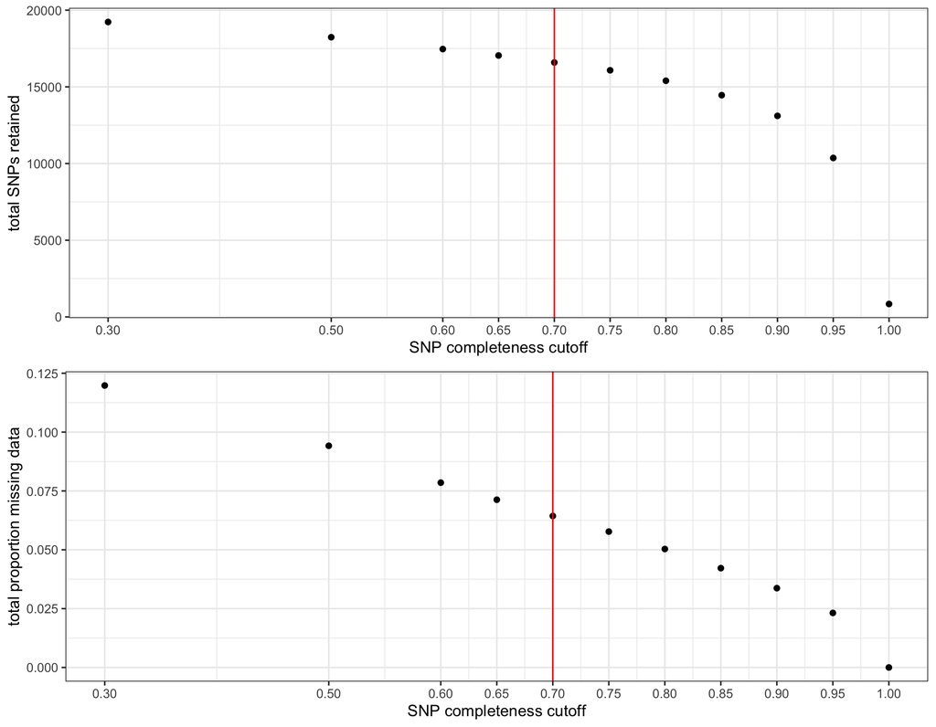

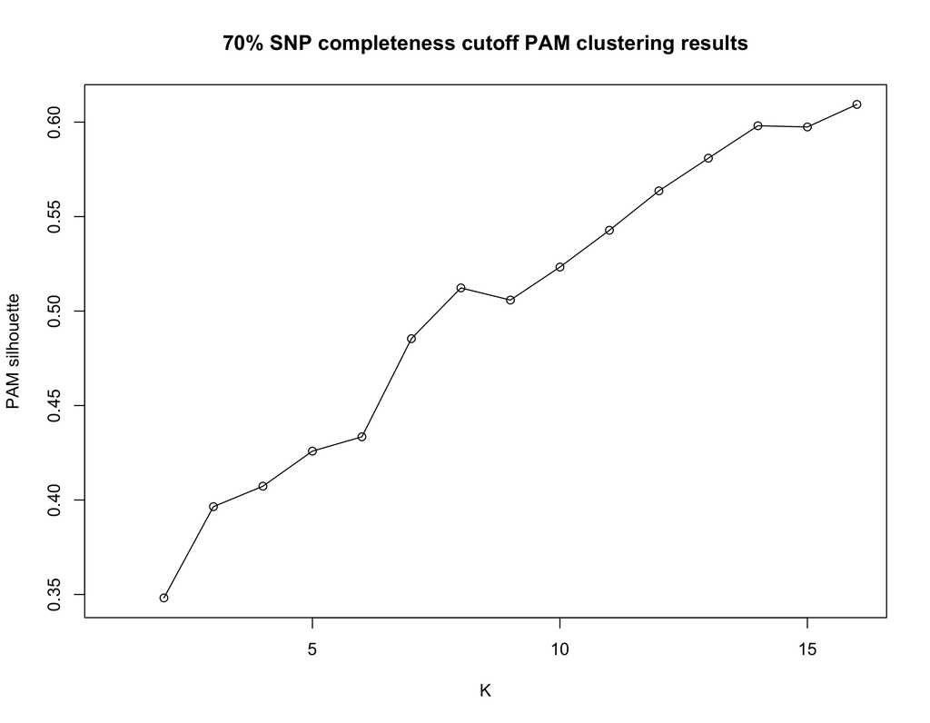

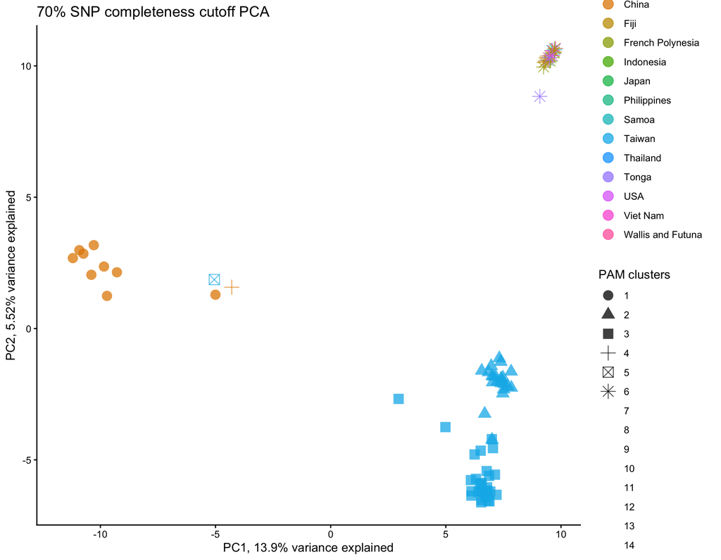

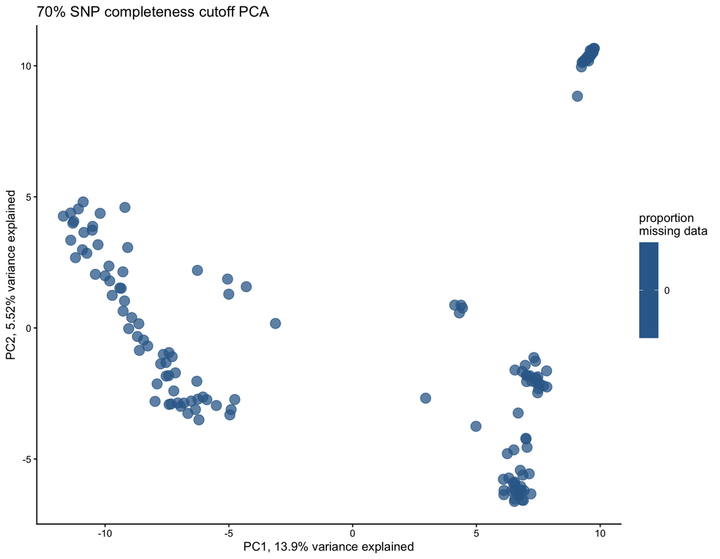

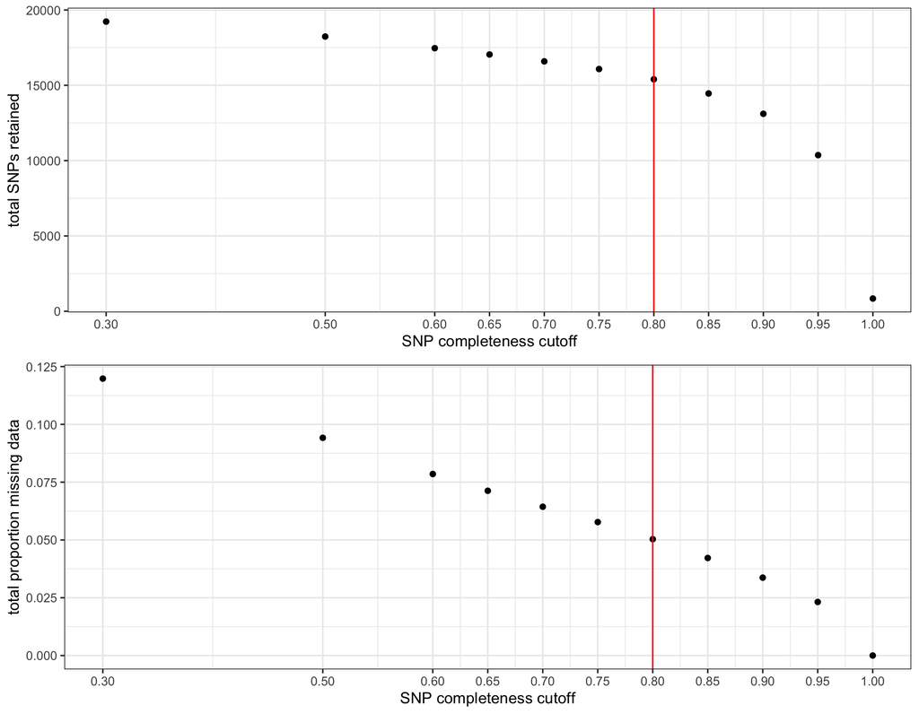

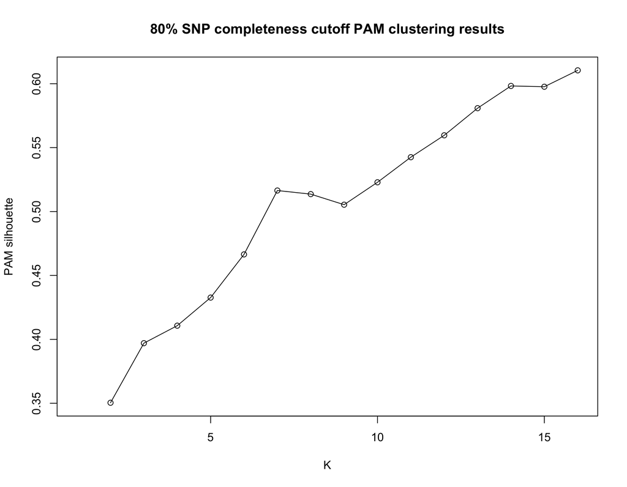

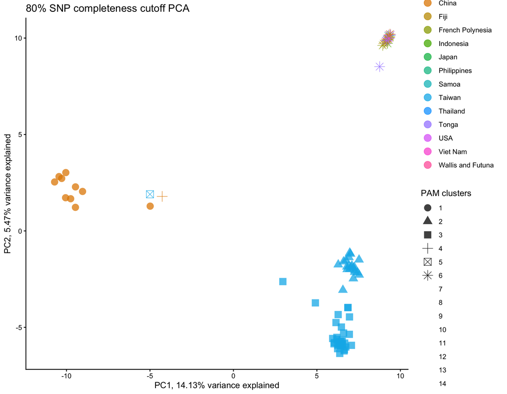

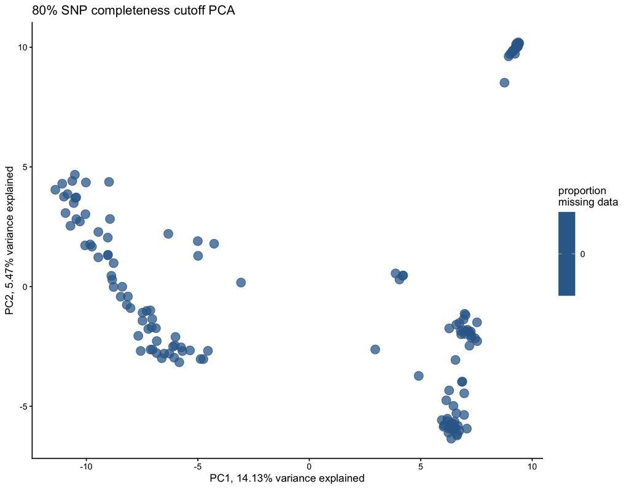

[output not shown]

[output cut: 1666 more lines]

[output not shown]